# Tidy Tuesday-2022-Week2- Bee colony

Import the libraries

```r
library(tidyverse)
library(readr)
library(ggthemes)
library(ggrepel)
```

Import the data

```r
colony <- readr::read_csv('https://raw.githubusercontent.com/rfordatascience/tidytuesday/master/data/2022/2022-01-11/colony.csv')
stressor <- readr::read_csv('https://raw.githubusercontent.com/rfordatascience/tidytuesday/master/data/2022/2022-01-11/stressor.csv')
```

```r
merge(colony, stressor, by=c('year','months','state'))-> colony_stressor

colony_stressor
```

| year | months | state | colony_n | colony_max | colony_lost | colony_lost_pct | colony_added | colony_reno | colony_reno_pct | stressor | stress_pct |
| --- | --- | --- | --- | --- | --- | --- | --- | --- | --- | --- | --- |
| 2015 | April-June | Alabama | 7500 | 7500 | 860 | 12 | 1900 | 680 | 9 | Varroa mites | 16.7 |
| 2015 | April-June | Alabama | 7500 | 7500 | 860 | 12 | 1900 | 680 | 9 | Other pests/parasites | 42.5 |
| 2015 | April-June | Alabama | 7500 | 7500 | 860 | 12 | 1900 | 680 | 9 | Disesases | NA |
| 2015 | April-June | Alabama | 7500 | 7500 | 860 | 12 | 1900 | 680 | 9 | Pesticides | 2.3 |
| 2015 | April-June | Alabama | 7500 | 7500 | 860 | 12 | 1900 | 680 | 9 | Other | 3.2 |
| 2015 | April-June | Alabama | 7500 | 7500 | 860 | 12 | 1900 | 680 | 9 | Unknown | 4.1 |
| 2015 | April-June | Arizona | 33000 | 33000 | 5500 | 17 | 19500 | 7000 | 21 | Varroa mites | 8.4 |
| 2015 | April-June | Arizona | 33000 | 33000 | 5500 | 17 | 19500 | 7000 | 21 | Other pests/parasites | 32.1 |
| 2015 | April-June | Arizona | 33000 | 33000 | 5500 | 17 | 19500 | 7000 | 21 | Disesases | 0.5 |
| 2015 | April-June | Arizona | 33000 | 33000 | 5500 | 17 | 19500 | 7000 | 21 | Pesticides | 20.1 |

[output cut: 990 more lines]

```r
NA
```

Is there any relationship between the year and number of Bee colonies destroyed?

```r
colony %>%
  group_by(year) %>%
  summarise(colony_lost=sum(colony_lost, na.rm=T)) %>%
  ungroup()-> col_lost_per_year
```

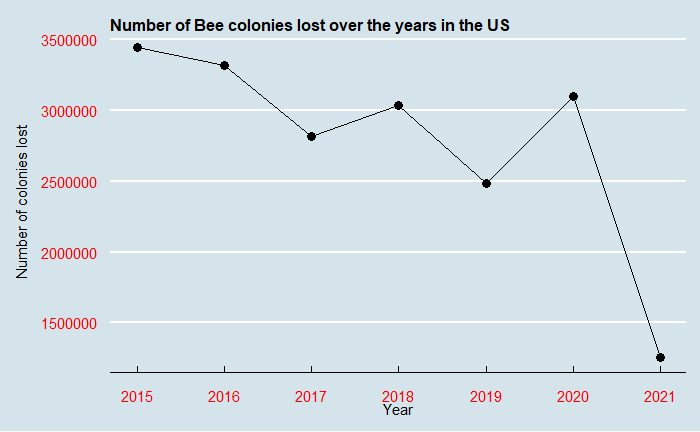

```r
ggplot(data=col_lost_per_year,aes(x=year, y=colony_lost))+
  geom_line()+
  geom_point(size=3)+
  theme_economist()+
  ylab('Number of colonies lost')+
  xlab('Year')+
  labs(title = 'Number of Bee colonies lost over the years in the US')+
  theme(plot.title = element_text(size=12),
        axis.text.x = element_text(color = 'red'),
        axis.text.y = element_text(color = 'red'),
        axis.title.x = element_text(margin = margin(r = 20)),
        axis.title.y = element_text(margin = margin(r = 10)))+
  scale_x_continuous(breaks=unique(col_lost_per_year$year))
```

Except 2021. We can’t see any clear correlation between the year and number of colonies destroyed. And for 2021, it may be the case that the data is not updated as the year just ended few days back.

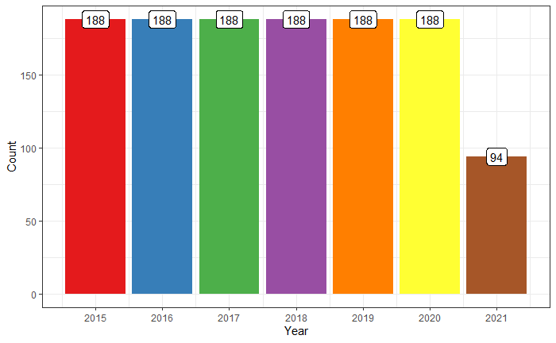

```r
colony %>%
  group_by(year) %>%
  summarise(count=n()) %>%
  ggplot()+
  geom_bar(aes(x=year, y=count, fill=as.character(year)), stat='identity')+
  scale_x_continuous(breaks=unique(col_lost_per_year$year))+
  theme_bw()+
  theme(legend.position = 'none')+
  geom_label(aes(x=year, y=count, label=count))+
  ylab('Count')+
  xlab('Year')+
  scale_fill_brewer(palette = 'Set1')
```

And that’s it. The data-set isn’t updated for 2021. So, we can say there isn’t any clear trend when it comes to the number of colonies lost over the years.

Let’s have a detailed look at the lost colonies in the US over the years.

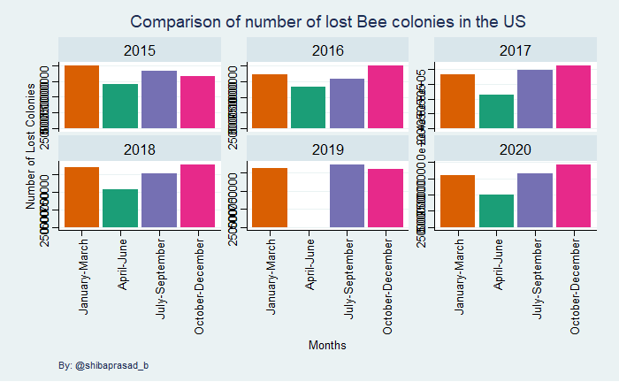

```r
colony %>%
  filter(year != 2021) %>%
  group_by(year, months) %>%
  summarise(colony_lost=sum(colony_lost, na.rm = T)) %>%
  ggplot()+
  geom_bar(aes(x=fct_relevel(months,'January-March','April-June','July-September','October-December'), y=colony_lost, fill=months, level = ), stat='identity')+
  geom_label_repel(aes(x=months, y=colony_lost, label=colony_lost))+
  facet_wrap(~year, scales = 'free_y')+
  labs(title='Comparison of number of lost Bee colonies in the US',
       caption = 'By: @shibaprasad_b')+
  theme_stata()+
  theme(axis.text.x = element_text(angle = 90, hjust = 1, vjust = 0.5),
        legend.position = 'none')+
  xlab('Months')+
  ylab('Number of Lost Colonies')+
  scale_fill_brewer(palette = 'Dark2')
```

Except 2015 and 2019. We can see that the number of colonies lost has been the highest for the October-December period.

Post the October-December period, the number of lost colonies has generally decreased up until April-June, Before increasing again from July-September.

Now we will see the number of colonies affected by different stressors. From the data source, it was not clear what they meant by ‘affected’. Were they lost? Or just some kind of adverse affect by the stressors?

Also, it is not completely clear how the percentage of colonies affected by stressors was claculated. Was it based on the maximum number of colonies? For this analysis, we will consider the maximum number of colonies.

```r
colony_stressor %>%
  mutate(colony_lost_pct=ifelse(is.na(colony_lost),round(ceiling(100*colony_lost/colony_max)),colony_lost_pct))-> colony_stressor
```

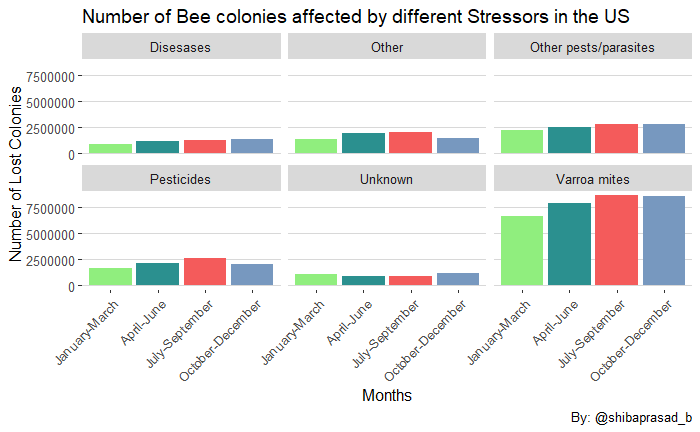

```r
colony_stressor %>%
  mutate(stress_n= (colony_max*stress_pct)/100) %>%
  group_by(stressor, months) %>%
  summarise(total_colonies_lost=as.numeric(sum(stress_n, na.rm=T))) %>%
  ungroup() %>%
  ggplot()+
  geom_bar(aes(x=fct_relevel(months,'January-March','April-June','July-September','October-December'), y=total_colonies_lost, fill=months, level = ), stat='identity')+
  facet_wrap(~stressor)+
  labs(title='Number of Bee colonies affected by different Stressors in the US',
       caption = 'By: @shibaprasad_b')+
  theme_hc()+
  theme(axis.text.x = element_text(angle = 45, hjust = 1),
        legend.position = 'none')+
  xlab('Months')+
  ylab('Number of Lost Colonies')+
  scale_fill_hc("darkunica")
```

```r
NA
NA
```

Varroa mites is the stressor that has affected the Bee colonies most. But the time of the year doesn’t seem to have a huge impact on it.

Let’s now have a look at the top 5 states with the most number of Bee colonies.

```r
colony %>%
  group_by(state) %>%
  summarise(total_colonies=sum(colony_max, na.rm = T)) %>%
  arrange(desc(total_colonies)) %>%
  top_n(5) %>%
  pull(state)-> top_5_states
top_5_states
```

```
[1] "California"   "North Dakota" "Texas"        "Florida"      "South Dakota"
```

Now let’s have a look at the Number of Bee colonies lost for the top 5 US states over the years.

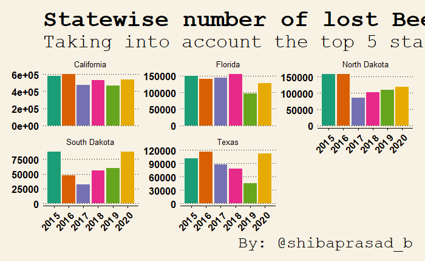

```r
colony %>%
  filter(state %in% top_5_states) %>%
  filter(year!=2021) %>%
  group_by(state, year) %>%
  summarise(total_lost_colonies=sum(colony_lost, na.rm = T)) %>%
  ggplot()+
  geom_bar(aes(x=year, y=total_lost_colonies, fill=as.factor(year), level = ), stat='identity')+
  facet_wrap(~state, scales = 'free_y')+
  labs(title='Statewise number of lost Bee colonies in the US over the years',
       subtitle = 'Taking into account the top 5 states with most number of colonies',
       caption = 'By: @shibaprasad_b',
       x='Year',
       y='Number of Lost Colonies')+
  theme_wsj()+
  theme(axis.text.x = element_text(angle = 45, hjust = 1),
        legend.position = 'none')+
  scale_x_continuous(breaks=unique(col_lost_per_year$year))+
  scale_fill_brewer(palette = 'Dark2')
```

For the two Dakota states, the number of Bee colonies destroyed have increased steadily since 2017. Texas was the only state for which the number of Bee colonies destroyed saw a gradual decrease from 2016 up until 2019.

2020 saw a steep rise in the number for most of the states. For Texas the number was more than 2x. Did this happen because of the Pandemic? The lives of Beekeepers were disrupted and they couldn’t pay the needed attention? To have a better understanding if that is the case, we should look at the % of colonies lost.

```r
colony %>%
  filter(state %in% top_5_states) %>%
  filter(year!=2021) %>%
  group_by(year) %>%
  summarise(total_colonies=sum(colony_max, na.rm = T),
            total_lost_colonies=sum(colony_lost, na.rm = T))-> yearwise_lost_colonies

colony %>%
  filter(state %in% top_5_states) %>%
  filter(year!=2021) %>%
  group_by(year, state) %>%
  summarise(total_colonies=sum(colony_max, na.rm = T),
            total_lost_colonies=sum(colony_lost, na.rm = T),
            per_lost=100*(total_lost_colonies/total_colonies))-> year_state_lost_colonies
```

[figure not shown]

For South Dakota the percentage has increased over the years but that’s not the case for other states. Infact for Florida, California and North Dakota, the percentage declined in 2020! So we can’t say that due to the disruption caused by the pandemic, many of the Bee colonies were destroyed.